# Pre-processing of *Strongyloides* spp. bulk RNA-seq for inclusion in *Strongyloides* RNA-Seq Browser

Astra S. Bryant, PhD

April 01, 2025

# 1 Introduction

The goal of this file is to arrange gene-centric *Strongyloides* RNA-seq data originally published by [Stolzfus *et al* 2012](https://journals.plos.org/plosntds/article?id=10.1371/journal.pntd.0001854) and [Gonzalez Akimori *et al* 2021](https://www.nature.com/articles/s41598-021-87478-3).

## 1.1 Update Notes

- RNA-seq expression data for *S. stercoralis* free-living males added on 11-03-21 (ASB).
- Re-ran Kallisto alignment with WBPS16 reference transcriptome on 11-06-21 (ASB).
- Force calls to BioMart to not use caching, and import Kallisto reads every time. This may disrupt preprocessing pipeline if the reference transcriptome version does not match the current version on ParaSite (11-11-21, ASB).
- Re-ran Kallisto alignment with WBPS17 reference transcriptome on 07-08-22 (ASB)
- Added additional annotation information, including XLOC gene annotations predicted by Vicky Hunt’s Lab. Also generated new streamline preprocessing RMD file. - 12-05-24 (ASB).

# 2 Pre-processing Methods Overview

For overview of methods, see Bryant *et al* 2023.

This document saves multiple files that are passed to a Shiny Web App for downstream browsing and on-demand analysis.

# 3 Code

Note: Code chunks are collated and echoed at the end of the document in Appendix I.

## 3.1 Import kallisto data into R and generate a Digital Gene Expression List

Generate a digital gene expression list that could be easily shared/loaded for downstream filtering/normalization.

```r
species_list <- tibble(species = c('Ss', 'Sr', 'Sp', 'Sv'))

for (x in species_list$species) {

output.path <- paste0("./Data/", x)

# read in the study design ----
targets <- read_tsv(paste0("./Data/", x, "/", x,"_studyDesign.txt"),
                    na = c("", "NA", "na"), show_col_types = F)

# load pre-generated annotation information
load(paste0("./Data/",x, "/", x,"_geneAnnotations"))

# create file paths to the abundance files generated by Kallisto
# using the 'file.path' function
path <- file.path("./Data", x, "Reads",
                  targets$sample,
                  "abundance.tsv")

# get annotations using organism-specific package ----
species <- switch(x,
                  `Ss` = 'ststerprjeb528',
                  `Sr` = 'strattprjeb125',
                  `Sp` = 'stpapiprjeb525',
                  `Sv` = 'stveneprjeb530')


Tx <- getBM(attributes=c('wbps_transcript_id',
                            'wbps_gene_id'),
               # grab the ensembl annotations for Wormbase Parasite genes
               mart = useMart(biomart="parasite_mart",
                              dataset = "wbps_gene",
                              host="https://release-18.parasite.wormbase.org", #Using the archived version of biomart because the XLOC gene ids are not useful.
                              port = 443),
               filters = c('species_id_1010'),
               useCache = FALSE,
               value = species) %>%
  as_tibble()



     #we need to rename the columns retrieved from biomart
    if (x == "Sr") {
        Tx<-Tx %>%
            dplyr::rename(target_id = wbps_transcript_id, WB_geneID = wbps_gene_id)  %>%
            dplyr::mutate(gene_name = str_remove_all(target_id, "\\.[0-9]$")) %>%
            dplyr::mutate(gene_name = str_remove_all(gene_name, "[a-c]$")) %>%
            dplyr::select(!WB_geneID)
    } else{
 Tx<-Tx %>%
  dplyr::rename(target_id = wbps_transcript_id,
                gene_name = wbps_gene_id)
}

# import Kallisto transcript counts into R using Tximport ----
# copy the abundance files to the working directory and
# rename so that each sample has a unique name
Txi_gene <- tximport(path,
                     type = "kallisto",
                     tx2gene = Tx[,1:2],
                     txOut = FALSE,
                     countsFromAbundance = "lengthScaledTPM",
                     ignoreTxVersion = FALSE)

counted_genes <- data.frame(geneID = rownames(Txi_gene$counts))
annotations_sub<-dplyr::semi_join(annotations, counted_genes, by = "geneID")
if (nrow(annotations_sub) == 0) {
    annotations_sub<-dplyr::semi_join(annotations, counted_genes, by = join_by("WBgeneID" == "geneID"))
}

# generate a DGEList
if (x == "Sr") {
myDGEList <- DGEList(Txi_gene$counts,
                     samples = data.frame(samples = targets$source,
                                          source = targets$sample),
                     group = targets$group,
                     genes = annotations_sub)
} else {
myDGEList <- DGEList(Txi_gene$counts,
                     samples = targets$sample,
                     group = targets$group,
                     genes = annotations_sub)
}
output.name <- paste0(x, '_DGEList')
save(myDGEList,
     file = file.path(output.path,
                      output.name))
}
```

## 3.2 Data Filtering and Normalization

1. Filter and normalize data.
2. Use `ggplot2` to visualize the impact of filtering and normalization on the data.
3. Save the following files and datasets:  
   i) filtered and normalized (but not voom adjusted) log2CPM values (all species).  
   ii) a matrix of discarded genes and their raw counts - this data is downloadable from within the Shiny Browser App (all species).

```r
species_list <- tibble(species = c('Ss', 'Sr', 'Sp', 'Sv'))
for (x in species_list$species) {
output.path <- paste0("./Data/", x)

# load pre-generated DGEList information
load(paste0(output.path,"/",x,"_DGEList"))

# load pre-generated annotation information
load(paste0(output.path,"/",x,"_geneAnnotations"))

# read in the study design ----
targets <- read_tsv(paste0("./Data/", x, "/", x,"_studyDesign.txt"),
                    na = c("", "NA", "na"), show_col_types = F)
# Generate life stage IDs
ids <- rep(cbind(targets$group),
           times = nrow(myDGEList$counts)) %>%
  as_factor()

# calculate and plot log2 counts per million ----
# use the 'cpm' function from EdgeR to get log2 counts per million
# then coerce into a tibble
log2.cpm.df.pivot <-cpm(myDGEList, log=TRUE) %>%
  as_tibble(rownames = "geneID") %>%
  setNames(nm = c("geneID", targets$sample)) %>%
  pivot_longer(cols = -geneID,
               names_to = "samples",
               values_to = "expression") %>%
  add_column(life_stage = ids)

# plot the data
p1 <- ggplot(log2.cpm.df.pivot) +
  aes(x=samples, y=expression, fill=life_stage) +
  geom_violin(trim = FALSE, show.legend = T, alpha= 0.7) +
  stat_summary(fun = "median",
               geom = "point",
               shape = 20,
               size = 2,
               color = "black",
               show.legend = FALSE) +
  labs(y="log2 expression", x = "sample",
       title = paste0(x, ": Log2 Counts per Million (CPM)"),
       subtitle="unfiltered, non-normalized",
       fill= "Life stage",
       caption=paste0("produced on ", Sys.time())) +
  theme_bw() +
  theme(text = element_text(size = 10),
        title = element_text(size = 10),
        axis.text.y = element_text (size = 5)) +
  coord_flip()

# Filter the data ----

# filter genes/transcripts with low counts
# how many genes had more than 1 CPM (TRUE) in at least n samples
# Note: The cutoff "n" is adjusted for the number of
# samples in the smallest group of comparison.
if (x == 'Ss'){
  keepers <- cpm(myDGEList) %>%
  rowSums(.>1)>=3
} else {
keepers <- cpm(myDGEList) %>%
  rowSums(.>1)>=1}

myDGEList.filtered <- myDGEList[keepers,]

ids.filtered <- rep(cbind(targets$group),
                    times = nrow(myDGEList.filtered)) %>%
  as_factor()

log2.cpm.filtered.df.pivot <- cpm(myDGEList.filtered, log=TRUE) %>%
  as_tibble(rownames = "geneID") %>%
  setNames(nm = c("geneID", targets$sample)) %>%
  pivot_longer(cols = -geneID,
               names_to = "samples",
               values_to = "expression") %>%
  add_column(life_stage = ids.filtered)

p2 <- ggplot(log2.cpm.filtered.df.pivot) +
  aes(x=samples, y=expression, fill=life_stage) +
  geom_violin(trim = FALSE, show.legend = T, alpha= 0.7) +
  stat_summary(fun = "median",
               geom = "point",
               shape = 20,
               size = 2,
               color = "black",
               show.legend = FALSE) +
  labs(y="log2 expression", x = "sample",
       title = paste0(x, ": Log2 Counts per Million (CPM)"),
       subtitle="filtered, non-normalized",
       fill = "Life stage",
       caption=paste0("produced on ", Sys.time())) +
  theme_bw() +
  theme(text = element_text(size = 10),
        title = element_text(size = 10),
        axis.text.y = element_text (size = 5)) +
  coord_flip()

# Look at the genes excluded by the filtering step ----
# just to check that there aren't any with
# high expression that are in few samples
# Discarded genes
myDGEList.discarded <- myDGEList[!keepers,]

ids.discarded <- rep(cbind(targets$group),
                     times = nrow(myDGEList.discarded)) %>%
  as_factor()

log2.cpm.discarded.df.pivot <- cpm(myDGEList.discarded, log=F) %>%
  as_tibble(rownames = "geneID") %>%
  setNames(nm = c("geneID", targets$sample)) %>%
  pivot_longer(cols = -geneID,
               names_to = "samples",
               values_to = "expression") %>%
  add_column(life_stage = ids.discarded)

# Genes that are above 1 cpm
log2.cpm.discarded.df.pivot %>%
  dplyr::filter(expression > 1)

# Generate a matrix of discarded genes and their raw counts ----
discarded.gene.df <- log2.cpm.discarded.df.pivot %>%
  pivot_wider(names_from = c(life_stage, samples),
              names_sep = "-",
              values_from = expression,
              id_cols = geneID)%>%
  left_join(annotations, by = "geneID")

# Plot discarded genes
p.discarded <- ggplot(log2.cpm.discarded.df.pivot) +
  aes(x=samples, y=expression, color=life_stage) +
  geom_jitter(alpha = 0.3, show.legend = T)+
  stat_summary(fun = "median",
               geom = "point",
               shape = 20,
               size = 2,
               color = "black",
               show.legend = FALSE) +
  labs(y="expression", x = "sample",
       title = paste0(x, ": Counts per Million (CPM)"),
       subtitle="genes excluded by low count filtering step, non-normalized",
       fill = "Life stage",
       caption=paste0("produced on ", Sys.time())) +
  theme_bw() +
  theme(text = element_text(size = 10),
        title = element_text(size = 10),
        axis.text.y = element_text (size = 5)) +
  coord_flip()


# Normalize the data using a between samples normalization ----
# Source for TMM sample normalization here:
# https://genomebiology.biomedcentral.com/articles/10.1186/gb-2010-11-3-r25
myDGEList.filtered.norm <- calcNormFactors(myDGEList.filtered, method = "TMM")

log2.cpm.filtered.norm <- cpm(myDGEList.filtered.norm, log=TRUE)

log2.cpm.filtered.norm.df<- cpm(myDGEList.filtered.norm, log=TRUE) %>%
  as_tibble(rownames = "geneID") %>%
  setNames(nm = c("geneID", targets$sample))

log2.cpm.filtered.norm.df.pivot<-log2.cpm.filtered.norm.df %>%
  pivot_longer(cols = -geneID,
               names_to = "samples",
               values_to = "expression") %>%
  add_column(life_stage = ids.filtered)

p3 <- ggplot(log2.cpm.filtered.norm.df.pivot) +
  aes(x=samples, y=expression, fill=life_stage) +
  geom_violin(trim = FALSE, show.legend = T, alpha = 0.7) +
  stat_summary(fun = "median",
               geom = "point",
               shape = 20,
               size = 2,
               color = "black",
               show.legend = FALSE) +
  labs(y="log2 expression", x = "sample",
       title = paste0(x, ": Log2 Counts per Million (CPM)"),
       subtitle="filtered, TMM normalized",
       fill = "Life stage",
       caption=paste0("produced on ", Sys.time())) +
  theme_bw() +
  theme(text = element_text(size = 10),
        title = element_text(size = 10),
        axis.text.y = element_text (size = 5)) +
  coord_flip()

# Save outputs
output.name <- paste0(x, '_FilteringNormalizationGraphs')
save(p1, p2, p3, p.discarded, discarded.gene.df,
     file = file.path(output.path,
                      output.name))

output.name <- paste0(x, '_FilteredNormalizedData')
save(myDGEList.filtered.norm, log2.cpm.filtered.norm,
     file = file.path(output.path,
                      output.name))

# Save a matrix of discarded genes and their raw counts ----
output.name <- paste0(x, '_discardedGenes.csv')
discarded.gene.df %>%
write.csv(file = file.path(app.path,
                           output.name))
discarded.gene.df %>%
write.csv(file = file.path(www.path,
                           output.name))

}
```

## 3.3 Variance Stabilization and EList Generation

The goal of this chunk is to fit data to a linear model for responsively detecting differentially expressed genes (DGEs) using `limma::voom`.

This chunk saves the variance-stabilized, filtered and normalized data as an R object with the suffix `_vDGEList`. It also saves a matrix of processed count data as a `.csv` file for downloading from the App.

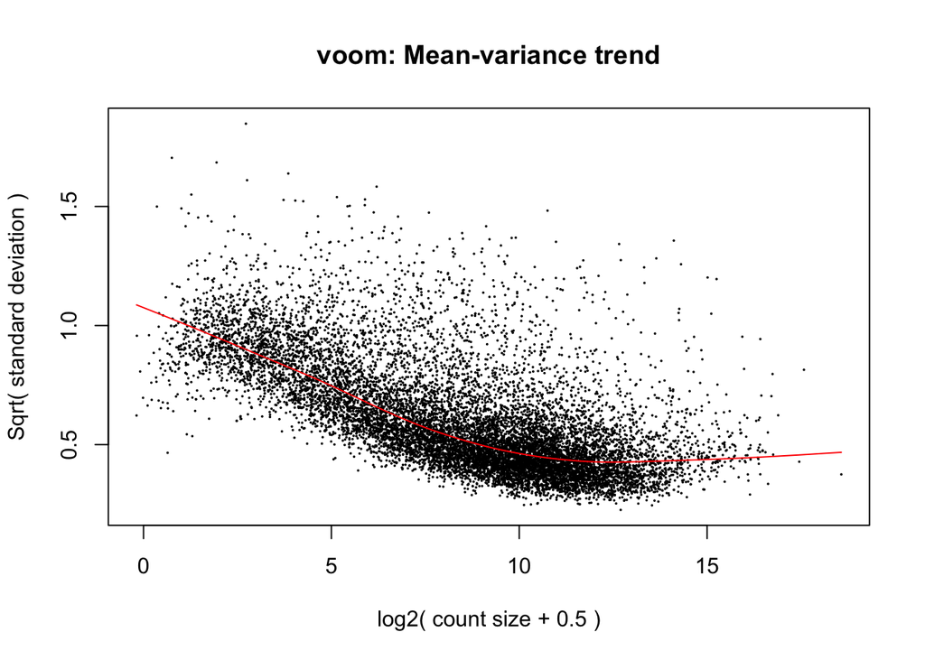

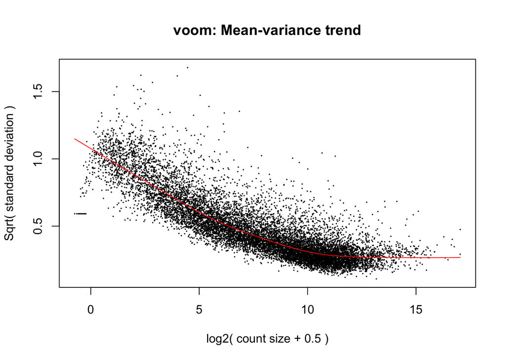

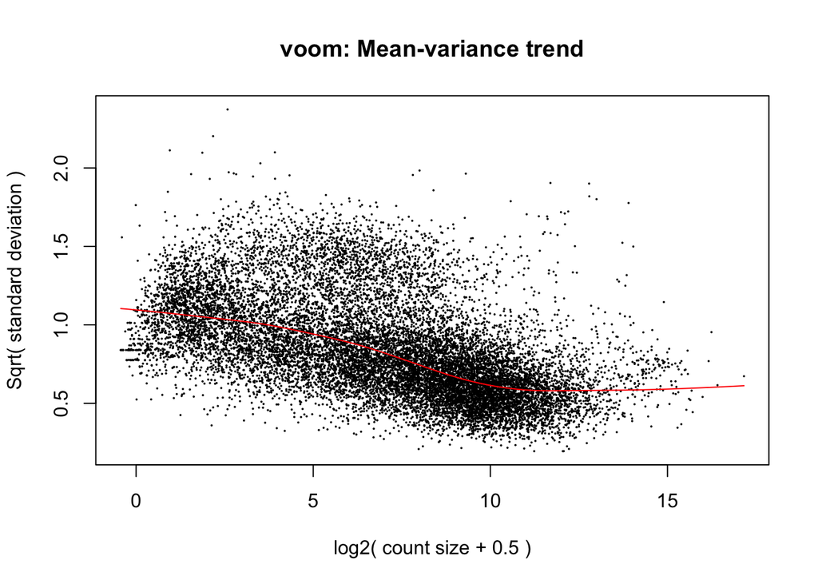

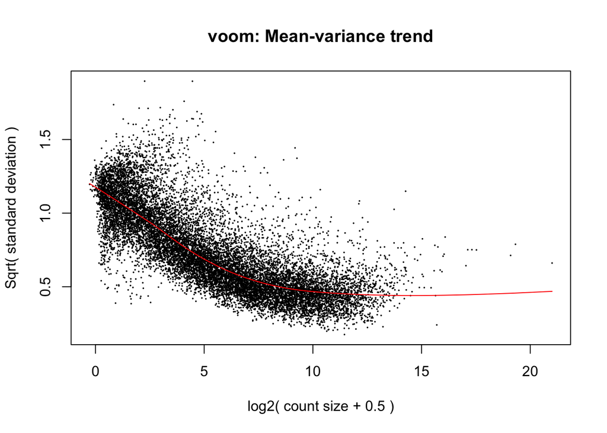

```r
# Compute Variance-Stabilized DGEList Object ----

species_list <- tibble(species = c('Ss', 'Sr', 'Sp', 'Sv'))
for (x in species_list$species) {

output.path <- paste0("./Data/", x)

# load pre-generated filtered and normalized data
load(paste0("./Data/",x,"/",x,"_FilteredNormalizedData"))

# read in the study design ----
targets <- read_tsv(paste0("./Data/", x, "/", x,"_studyDesign.txt"),
                    na = c("", "NA", "na"), show_col_types = F)

# Set up the design matrix ----
if (x == 'Sv' | x == 'Sr'){
  group <- factor(targets$group)
  biolrep <- factor(targets$source)

  design <- model.matrix(~0 + group)
  colnames(design) <- levels(group)

# Model mean-variance trend and fit linear model to data ----
# Use VOOM function from Limma package to model the mean-variance relationship
# produces a variance-stabilized DGEList, that include precision
# weights for each gene to try and control for heteroscedasity.
# transforms count data to log2-counts per million
# Outputs: E = normalized expression values on the log2 scale
v.DGEList.filtered.norm.withtechreplicates <- voom(counts = myDGEList.filtered.norm,
                                design = design, plot = T)


v.DGEList.filtered.norm <- avearrays(v.DGEList.filtered.norm.withtechreplicates,
                                     biolrep)

v.DGEList.filtered.norm$targets$samples <- targets$source[!duplicated(biolrep)]
colnames(v.DGEList.filtered.norm) <- paste(v.DGEList.filtered.norm$targets$group,
                                            v.DGEList.filtered.norm$targets$samples,sep = '-')
colnames(v.DGEList.filtered.norm$E) <- paste(v.DGEList.filtered.norm$targets$group,
                                             letters[ave(seq_along(v.DGEList.filtered.norm$targets$group), v.DGEList.filtered.norm$targets$group, FUN = seq_along)], sep = '-')
} else {

# no intercept/blocking for matrix, comparisons across group
  group <- factor(targets$group)
  design <- model.matrix(~0 + group)
  colnames(design) <- levels(group)

# Model mean-variance trend and fit linear model to data ----
# Use VOOM function from Limma package to model the mean-variance relationship
# produces a variance-stabilized DGEList, that include precision
# weights for each gene to try and control for heteroscedasity.
# transforms count data to log2-counts per million
# Outputs: E = normalized expression values on the log2 scale
v.DGEList.filtered.norm <- voom(counts = myDGEList.filtered.norm,
                                design = design, plot = T)
colnames(v.DGEList.filtered.norm)<-targets$sample
colnames(v.DGEList.filtered.norm$E) <- paste(targets$group,
                                             targets$uniqueness_suffix,sep = '-')

}

# Fit and save a linear model to the data
fit <- lmFit(v.DGEList.filtered.norm, v.DGEList.filtered.norm$design)
output.name <- paste0(x, "_lmFit")
save(fit, file = file.path(app.path,
                      output.name))

# Save matrix of genes and their filtered, normalized, voom-transformed counts in Shiny app download (www) folder ----
# This is the count data that underlies the differential expression analyses in the Shiny app.
output.name <- paste0(x, '_log2cpm_filtered_norm_voom.csv')
write.csv(v.DGEList.filtered.norm$E,
          file = file.path(www.path,
                           output.name))

# Save v.DGEList in Shiny app Data folder----
output.name <- paste0(x, '_vDGEList')
save(v.DGEList.filtered.norm,
     file = file.path(app.path,
                      output.name))
}
```

## 3.4 Multivariate Analysis

```r
species_list <- tibble(species = c('Ss', 'Sr', 'Sp', 'Sv'))

for (x in species_list$species) {
  # read in DGElist object
  output.name <- paste0(x, '_vDGEList')
  output.path <- paste0("./Data/", x)

  load(file = file.path(app.path, output.name))

  # read in the study design ----
targets <- read_tsv(paste0("./Data/", x, "/", x,"_studyDesign.txt"),
                    na = c("", "NA", "na"), show_col_types = F)
# Perform multivariate analysis on the data
# Identify variables of interest in study design file ----
group <- factor(targets$group)

# Hierarchical clustering ---------------
# Remember: hierarchical clustering can only work on a data matrix, not a data frame

# Calculate distance matrix
# dist calculates distance between rows, so transpose data so that we get distance between samples.
# how similar are samples from each other
distance <- dist(t(v.DGEList.filtered.norm$E), method = "maximum") #other distance methods are "euclidean", maximum", "manhattan", "canberra", "binary" or "minkowski"

# Calculate clusters to visualize differences. This is the hierarchical clustering.
# The methods here include: single (i.e. "friends-of-friends"), complete (i.e. complete linkage), and average (i.e. UPGMA). Here's a comparison of different types: https://en.wikipedia.org/wiki/UPGMA#Comparison_with_other_linkages
clusters <- hclust(distance, method = "complete") #other agglomeration methods are "ward.D", "ward.D2", "single", "complete", "average", "mcquitty", "median", or "centroid"
dend <- as.dendrogram(clusters)

p4<-dend %>%
  dendextend::set("hang_leaves", c(0.1)) %>%
  dendextend::set("labels_cex", c(0.5)) %>%
  dendextend::set("branches_lwd", c(0.7)) %>%
  as.ggdend %>%
  ggplot (offset_labels = -0.5) +
  theme_dendro() +
  ylim(-8, max(get_branches_heights(dend))) +
  labs(title = "Hierarchical Cluster Dendrogram ",
       subtitle = "filtered, TMM normalized",
       y = "Distance",
       x = "Life stage") +
  coord_fixed(1/2) +
  theme(axis.title.x = element_text(color = "black"),
        axis.title.y = element_text(angle = 90),
        axis.text.y = element_text(angle = 0),
        axis.line.y = element_line(color = "black"),
        axis.ticks.y = element_line(color = "black"),
        axis.ticks.length.y = unit(2, "mm"))

# Principal component analysis (PCA) -------------
# this also works on a data matrix, not a data frame
pca.res <- prcomp(t(v.DGEList.filtered.norm$E), scale.=F, retx=T)
summary(pca.res) # Prints variance summary for all principal components.

#pca.res$rotation #$rotation shows you how much each gene influenced each PC (called 'scores')
#pca.res$x # 'x' shows you how much each sample influenced each PC (called 'loadings')
#note that these have a magnitude and a direction (this is the basis for making a PCA plot)
## This generates a screeplot: a standard way to view eigenvalues for each PCA. Shows the proportion of variance accounted for by each PC. Plotting only the first 10 dimensions.
p5<-fviz_eig(pca.res,
             #barcolor = brewer.pal(8,"Pastel2")[8],
             #barfill = brewer.pal(8,"Pastel2")[8],
             linecolor = "black",
             main = "Scree plot: proportion of variance accounted for by each principal component", ggtheme = theme_bw())

pc.var<-pca.res$sdev^2 # sdev^2 captures these eigenvalues from the PCA result
pc.per<-round(pc.var/sum(pc.var)*100, 1) # we can then use these eigenvalues to calculate the percentage variance explained by each PC

# Visualize the PCA result ------------------
#lets first plot any two PCs against each other
#We know how much each sample contributes to each PC (loadings), so let's plot
pca.res.df <- as_tibble(pca.res$x[,1:2]) %>%
  add_column(group = v.DGEList.filtered.norm$targets$group)
# Plotting PC1 and PC2

p6<-ggplot(pca.res.df) +
  aes(x=PC1, y=PC2,
      label = group,
      fill = group,
      color = group
  ) +
  geom_point(size=4) +
  xlab(paste0("PC1 (",pc.per[1],"%",")")) +
  ylab(paste0("PC2 (",pc.per[2],"%",")")) +
  labs(title="Principal Components Analysis",
       sub = "Note: analysis is blind to sample identity.",
       fill = "Life stage",
       color = "Life stage") +
  scale_x_continuous(expand = c(.3, .3)) +
  scale_y_continuous(expand = c(.3, .3)) +
  coord_fixed() +
  theme_bw() +
  theme(text = element_text(size = 10),
        title = element_text(size = 10))


# Create a PCA 'small multiples' chart ----
if (ncol(pca.res$x)>5){
  pca.res.df <- pca.res$x[,1:6]
  } else {
  pca.res.df <- pca.res$x[,1:ncol(pca.res$x)]
}

pca.res.df <- pca.res.df %>%
  as_tibble() %>%
  add_column(sample = v.DGEList.filtered.norm$targets$samples,
             group = v.DGEList.filtered.norm$targets$group)

pca.pivot <- pivot_longer(pca.res.df, # dataframe to be pivoted
                          cols = PC1:PC3, # column names to be stored as a SINGLE variable
                          names_to = "PC", # name of that new variable (column)
                          values_to = "loadings") # name of new variable (column) storing all the values (data)
PC1<-subset(pca.pivot, PC == "PC1")
PC2 <-subset(pca.pivot, PC == "PC2")
PC3 <- subset(pca.pivot, PC == "PC3")
#PC4 <- subset(pca.pivot, PC == "PC4")

# New facet label names for PCs
PC.labs <- c(paste0("PC1 (",pc.per[1],"%",")"),
             paste0("PC2 (",pc.per[2],"%",")"),
             paste0("PC3 (",pc.per[3],"%",")")
)
names(PC.labs) <- c("PC1", "PC2", "PC3")

p7<-ggplot(pca.pivot) +
  aes(x=sample, y=loadings) + # you could iteratively 'paint' different co-variates onto this plot using the 'fill' aes
  geom_bar(stat="identity") +
  facet_wrap(~PC, labeller = labeller(PC = PC.labs)) +
  geom_bar(data = PC1, stat = "identity", aes(fill = group)) +
  geom_bar(data = PC2, stat = "identity", aes(fill = group)) +
  geom_bar(data = PC3, stat = "identity", aes(fill = group)) +
  labs(title="PCA 'small multiples' plot",
       fill = "Life stage",
       caption=paste0("produced on ", Sys.time())) +
  scale_x_discrete(limits = v.DGEList.filtered.norm$targets$samples, labels = v.DGEList.filtered.norm$targets$group) +
  theme_bw() +
  theme(text = element_text(size = 5),
        title = element_text(size = 5))+
  coord_flip()

# Save plot outputs
output.name <- paste0(x, '_PCAGraphs')
save(p4, p5, p6, p7,
     file = file.path(output.path,
                      output.name))
}
```

# 4 Filtering and Normalization Results

## 4.1 *S. stercoralis* Filtering Results

### 4.1.1 Unfiltered, non-normalized log2CPM data

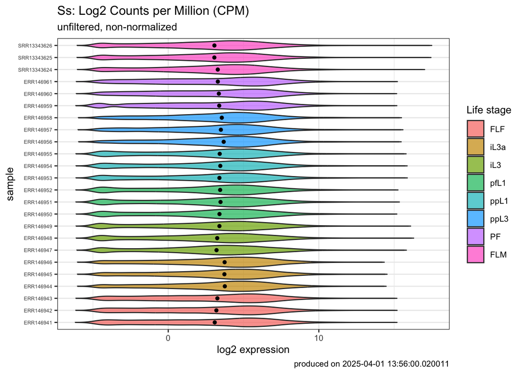

### 4.1.2 Filtered, non-normalized log2CPM data

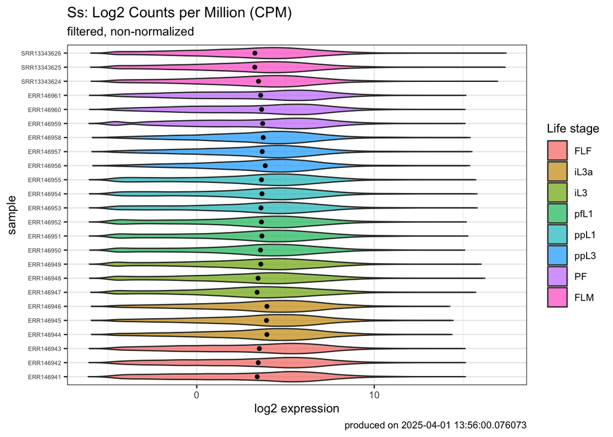

### 4.1.3 Filtered, normalized log2CPM data by life stage

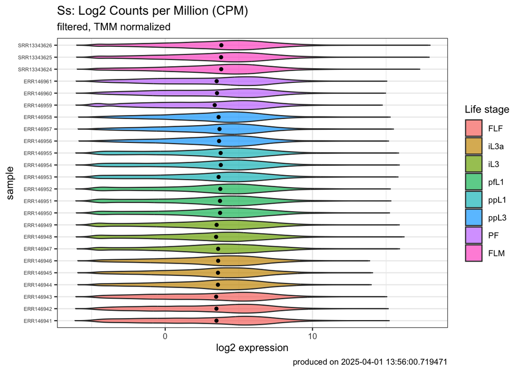

### 4.1.4 Genes discarded by low-copy filtering step

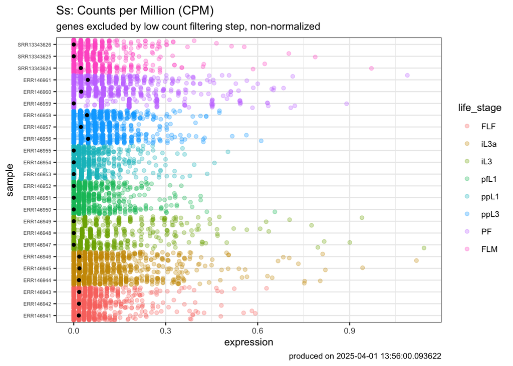

### 4.1.5 Discarded gene list

| geneID | FLF-ERR146941 | FLF-ERR146942 | FLF-ERR146943 | iL3a-ERR146944 | iL3a-ERR146945 | iL3a-ERR146946 | iL3-ERR146947 | iL3-ERR146948 | iL3-ERR146949 | pfL1-ERR146950 | pfL1-ERR146951 | pfL1-ERR146952 | ppL1-ERR146953 | ppL1-ERR146954 | ppL1-ERR146955 | ppL3-ERR146956 | ppL3-ERR146957 | ppL3-ERR146958 | PF-ERR146959 | PF-ERR146960 | PF-ERR146961 | FLM-SRR13343624 | FLM-SRR13343626 | FLM-SRR13343625 | XLOC_IDs | Location | Description | InterPro | GO_term | … |
| --- | --- | --- | --- | --- | --- | --- | --- | --- | --- | --- | --- | --- | --- | --- | --- | --- | --- | --- | --- | --- | --- | --- | --- | --- | --- | --- | --- | --- | --- | --- |
| SSTP_0000000200 | 0.05540402421224991 | 0.05405814581762206 | 0.05606900252437075 | 0 | 0 | 0 | 0 | 0 | 0 | 0 | 0 | 0.01847679802932296 | 0 | 0 | 0 | 0.03413895304535728 | 0 | 0 | 0 | 0.1771841446663665 | 0.04251300864380593 | 0 | 0 | 0 |  |  | Chromo domain-containing protein | Chromo/chromo_shadow_dom, Chromo-like_dom_sf, Chromo_domain |  | … |
| SSTP_0000000700 | 0 | 0 | 0.05328385598653353 | 0 | 0 | 0.08788621047838895 | 0 | 0 | 0 | 0 | 0 | 0 | 0 | 0 | 0 | 0 | 0.008768079745667911 | 0 | 0 | 0 | 0.02319262680857723 | 0 | 0 | 0 | XLOC_009263 \| TCONS_00013380.p1 | Ss_chrX.2 | LAGLIDADG_2 domain-containing protein |  |  | … |
| SSTP_0000000900 | 0.01664821699448192 | 0.05158391754699165 | 0 | 0.255967958377671 | 0.1470262652218387 | 0.1632320557495255 | 0 | 0 | 0.03690629324740356 | 0 | 0 | 0.01828572233880852 | 0 | 0 | 0.01643655059894111 | 0.07071363612537779 | 0.02347586213517321 | 0.1104386675079564 | 0 | 0.1936546093814709 | 0.1861980086873355 | 0.04670583621339051 | 0.04616542428057736 | 0 | XLOC_009264 \| TCONS_00013381.p1 | Ss_chrX.2 | Integrase catalytic domain-containing protein | Integrase_cat-core, RNaseH-like_sf, RNaseH_sf | nucleic acid binding, DNA integration | … |
| SSTP_0000001000 | 0.01686074242650958 | 0.01720133422170349 | 0.05405415299575572 | 0.2913243651438232 | 0.205186657069154 | 0.3796362990737305 | 0 | 0.02764964517912856 | 0 | 0 | 0 | 0.03694790670894674 | 0.02535072584384277 | 0 | 0 | 0.2353813877340186 | 0.07016561179366038 | 0.08705052991350097 | 0 | 0.2196641845647986 | 0.2073769580329633 | 0.07040615797081341 | 0.02336182728451185 | 0.08579950442193077 | XLOC_009264 \| TCONS_00014081.p1 | Ss_chrX.2 | Reverse transcriptase domain-containing protein | RT_dom, Rev_trsase/Diguanyl_cyclase, DNA/RNA_pol_sf |  | … |
| SSTP_0000001050 | 0.01664094852377771 | 0.01742015667803943 | 0 | 0.1196013275196641 | 0.05488702897960884 | 0.05457028023165708 | 0 | 0 | 0.03679571101387674 | 0 | 0 | 0 | 0 | 0 | 0 | 0.04731986279791201 | 0.02364951631811942 | 0.08938073353874271 | 0.09083691822023637 | 0.04840981925728395 | 0 | 0.1175437528333051 | 0.06925165520271705 | 0.02120879695310562 | XLOC_009264 \| TCONS_00014081.p1 | Ss_chrX.2 | FERM domain-containing protein |  |  | … |
| SSTP_0000001100 | 0 | 0.01717759047749996 | 0.07173356946872896 | 0.2223511592166592 | 0.09266272069199799 | 0.1632537589041125 | 0 | 0 | 0 | 0 | 0.01644726822202047 | 0 | 0 | 0.01647315433292714 | 0 | 0.02358429190963457 | 0.04687904100595759 | 0.1974636371610427 | 0.09065509983905534 | 0.09729098128090838 | 0.1390810349381951 | 0.07022963832099302 | 0.02323250747750343 | 0.1066235381984842 | XLOC_009264 \| TCONS_00013383.p1 | Ss_chrX.2 |  |  |  | … |
| SSTP_0000001200 | 0 | 0 | 0 | 0.05136739437160988 | 0.05602496471364959 | 0.05403370976250473 | 0 | 0 | 0 | 0 | 0 | 0 | 0.02526025773959171 | 0.01636538269278836 | 0 | 0.0469549341855177 | 0 | 0.02163936007378718 | 0 | 0.1708462473075188 | 0.09173320841975031 | 0.0234588318277007 | 0 | 0.02147064605268778 | XLOC_009264 \| TCONS_00013384.p1 | Ss_chrX.2 | Regulator of chromosome condensation |  |  | … |
| SSTP_0000001400 | 0 | 0 | 0 | 0.01695613571078437 | 0 | 0 | 0 | 0 | 0 | 0.01669670426448348 | 0 | 0 | 0 | 0.01666605412605124 | 0 | 0 | 0.0235982041840975 | 0 | 0.180484365736568 | 0.0964045371683991 | 0 | 0 | 0 | 0 |  |  | Reverse transcriptase Ty1/copia-type domain-containing protein |  |  | … |
| SSTP_0000001425 | 0.01658155008821225 | 0.01732095541428245 | 0 | 0.01701703821229047 | 0.01822791184025719 | 0.03621406163156093 | 0 | 0 | 0 | 0 | 0 | 0 | 0 | 0 | 0 | 0.02354437025929502 | 0.02352933140740201 | 0.04444519206989412 | 0 | 0.09640753247197803 | 0.09345745680860126 | 0.02338156294795702 | 0 | 0 |  |  | PP_kinase_C domain-containing protein |  |  | … |
| SSTP_0000001450 | 0 | 0 | 0 | 0.01693352538970946 | 0.01814879529173909 | 0.01803658192518315 | 0 | 0 | 0 | 0.01669102487462651 | 0.03268332071115566 | 0.01801255264765943 | 0 | 0.01666203697818613 | 0.05025208289802672 | 0 | 0.02358927384205671 | 0 | 0 | 0 | 0.02331846884669865 | 0 | 0 | 0 |  |  | Gag-pol polyprotein |  |  | … |

[output cut: 597 more lines]

## 4.2 *S. ratti* Filtering Results

### 4.2.1 Unfiltered, non-normalized log2CPM data

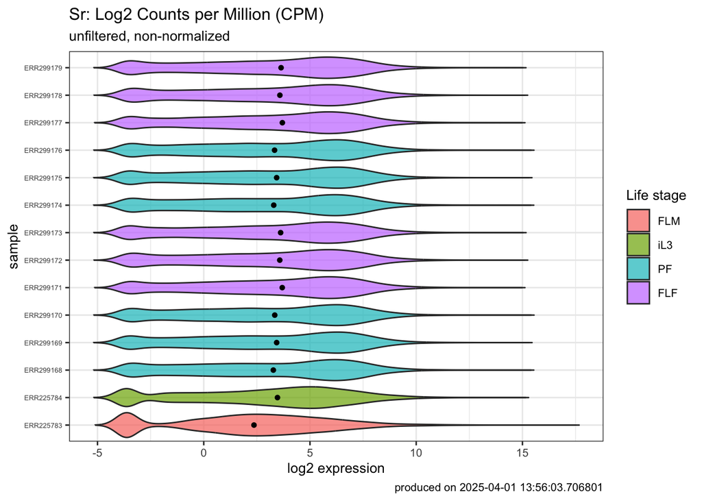

### 4.2.2 Filtered, non-normalized log2CPM data

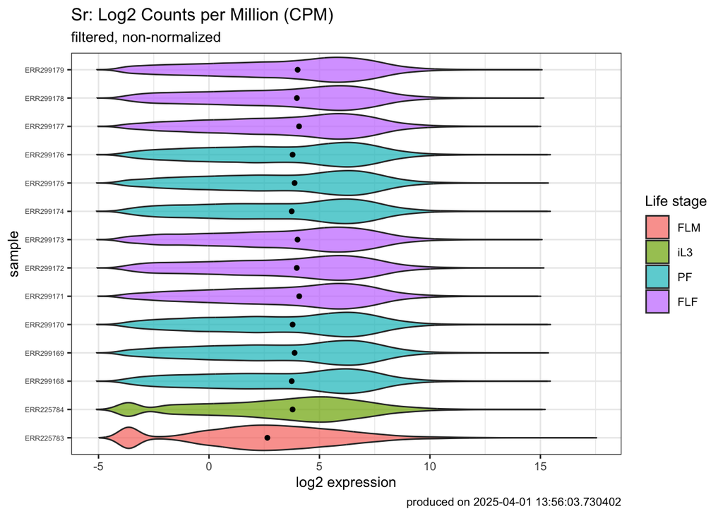

### 4.2.3 Filtered, normalized log2CPM data by life stage

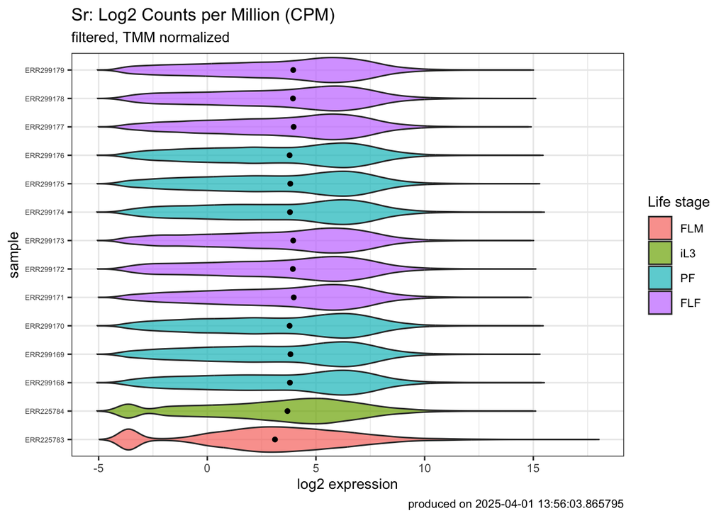

### 4.2.4 Genes discarded by low-copy filtering step

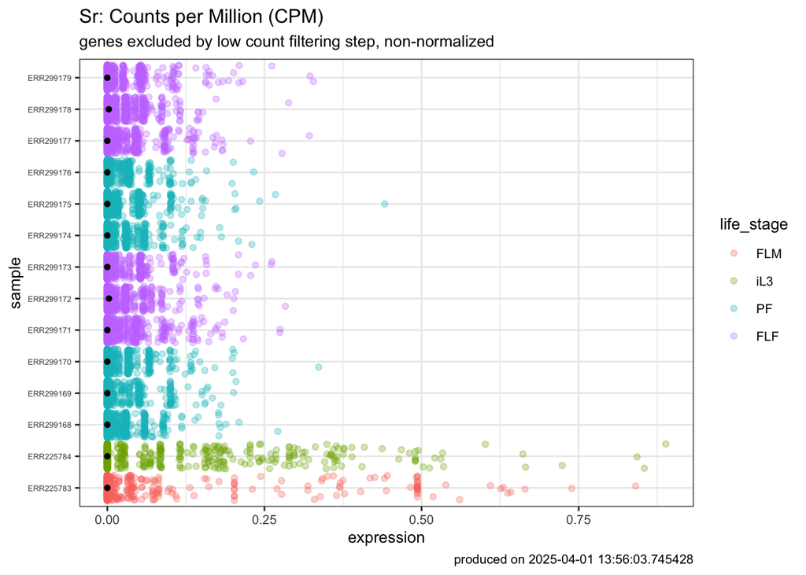

### 4.2.5 Discarded gene list

| geneID | FLM-ERR225783 | iL3-ERR225784 | PF-ERR299168 | PF-ERR299169 | PF-ERR299170 | FLF-ERR299171 | FLF-ERR299172 | FLF-ERR299173 | PF-ERR299174 | PF-ERR299175 | PF-ERR299176 | FLF-ERR299177 | FLF-ERR299178 | FLF-ERR299179 | WBgeneID | Location | Description | InterPro | GO_term | UniProtKB | GS1_homologID | GS1_percent_homology | GS2_homologID | GS2_percent_homology | GS3_homologID | GS3_percent_homology | GS4_homologID | GS4_percent_homology |
| --- | --- | --- | --- | --- | --- | --- | --- | --- | --- | --- | --- | --- | --- | --- | --- | --- | --- | --- | --- | --- | --- | --- | --- | --- | --- | --- | --- | --- |
| SRAE_0000000250 | 0 | 0 | 0.02959533611934536 | 0 | 0.03322062854926282 | 0 | 0 | 0.05207919358226856 | 0 | 0 | 0 | 0 | 0 | 0 | WBGene00255739 | SRAE_scaffold1 | 7TM GPCR, serpentine receptor class r (Str) family-containing protein | 7TM_GPCR_serpentine_rcpt_Str | membrane | A0A090KTM4 | SSTP_0000166700 \| SSTP_0000166700 | 63.3431 | SPAL_0000619700 | 43.9883 | SVE_1102400 | 22.5806 |  |  |
| SRAE_0000008800 | 0 | 0.1753500070815911 | 0 | 0 | 0 | 0 | 0 | 0 | 0 | 0 | 0 | 0 | 0.02809012658371392 | 0 | WBGene00255825 | SRAE_scaffold1 | GPCR, rhodopsin-like, 7TM domain-containing protein | GPCR_Rhodpsn_7TM | membrane | A0A090KU60 | SSTP_0000379900 | 42.0382 |  |  | SVE_1077100 | 39.4904 |  |  |
| SRAE_0000009200 | 0 | 0.3545826776674896 | 0 | 0 | 0 | 0.1362861792109752 | 0.02859270228704749 | 0 | 0 | 0 | 0.03314431283708828 | 0.09109878048594805 | 0 | 0 | WBGene00255829 | SRAE_scaffold1 | GPCR, rhodopsin-like, 7TM domain and 7TM GPCR,olfactory receptor/chemoreceptor Srsx family-containing protein | GPCR_Rhodpsn_7TM, 7TM_GPCR_Srsx | membrane | A0A090KTW0 | SSTP_0000379500 | 67.2269 | SPAL_0000399433 | 52.6611 | SVE_1077400 | 24.6499 |  |  |
| SRAE_0000009300 | 0 | 0 | 0 | 0 | 0.03333516046678273 | 0.04560142502304309 | 0 | 0 | 0.02984804595632728 | 0 | 0 | 0 | 0 | 0 | WBGene00255830 | SRAE_scaffold1 | Serpentine receptor class gamma | 7TM_GPCR_serpentine_rcpt_Srg | membrane, sensory perception of chemical stimulus, transmembrane signaling receptor activity | A0A090KU65 | SSTP_0000379400 \| SSTP_0000379400 | 78.6957 | SPAL_0000399466 | 69.1304 |  |  |  |  |
| SRAE_0000012700 | 0 | 0 | 0.0585625529660963 | 0.1053482109248011 | 0.0685291568630247 | 0 | 0.05673014050954902 | 0.05197966784489937 | 0.1185781447308043 | 0 | 0 | 0.04298582502332858 | 0.05423941936672866 | 0.05667050662963444 | WBGene00255864 | SRAE_scaffold1 | Serpin domain-containing protein | Serpin_fam, Serpin_dom, Serpin_sf, Serpin_sf_1 | serine-type endopeptidase inhibitor activity, negative regulation of peptidase activity, peptidase inhibitor activity, extracellular space | A0A090KTZ6 |  |  |  |  |  |  |  |  |
| SRAE_0000016250 | 0.5183762711145468 | 0 | 0 | 0 | 0 | 0 | 0 | 0 | 0 | 0 | 0 | 0 | 0 | 0 | WBGene00255901 | SRAE_scaffold1 | Serpentine receptor class gamma | 7TM_GPCR_serpentine_rcpt_Srg | membrane, sensory perception of chemical stimulus, transmembrane signaling receptor activity | A0A090KYS0 | SSTP_0000732800 | 71.0801 | SPAL_0001177825 | 45.993 | SVE_0755400 | 57.4913 |  |  |
| SRAE_0000022000 | 0 | 0 | 0 | 0 | 0 | 0 | 0 | 0 | 0 | 0 | 0 | 0 | 0 | 0 | WBGene00255960 | SRAE_scaffold1 | NADH dehydrogenase subunit 4L |  | membrane | A0A090KUA9 |  |  |  |  |  |  |  |  |
| SRAE_0000024200 | 0 | 0 | 0.05921890098166176 | 0.05026145967378458 | 0.0998148543452776 | 0.09171458542499626 | 0.02875983570592108 | 0 | 0 | 0.05038476463003209 | 0.03339025639652599 | 0.04598226811850291 | 0.02885289841021232 | 0.1565971142741015 | WBGene00255982 | SRAE_scaffold1 | 7TM GPCR, serpentine receptor class v (Srv) family-containing protein | 7TM_GPCR_serpentine_rcpt_Srv | membrane | A0A090KZ02 | SSTP_0000211050 \| SSTP_0000211050 | 40.6193 | SPAL_0000997200 | 35.5191 | SVE_0587600 | 34.4262 |  |  |
| SRAE_0000025300 | 0.4440465220535382 | 0 | 0.0304339617549741 | 0.05197801944687264 | 0.03385638733936849 | 0.04387708135643921 | 0.08827193326365071 | 0 | 0 | 0 | 0.0342868672205805 | 0.1702997854614647 | 0 | 0.05640618885813189 | WBGene00255993 | SRAE_scaffold1 |  |  |  | A0A090MS94 | SSTP_0001042950 | 69.1057 | SPAL_0001739750 | 57.7236 | SVE_1618900 | 61.7886 |  |  |
| SRAE_0000028000 | 0 | 0 | 0.08911371746493107 | 0 | 0.06636839683424219 | 0.0451504359462872 | 0.02895243990222758 | 0 | 0.05958723320549057 | 0.05046769699508458 | 0.03328809275744469 | 0 | 0.02897493416151682 | 0 | WBGene00256022 | SRAE_scaffold1 |  |  | membrane | A0A090KZ51 | SSTP_0000209700 | 61.4583 |  |  | SVE_1996000 | 32.8125 |  |  |

[output cut: 828 more lines]

## 4.3 *S. venezuelensis* Filtering Results

### 4.3.1 Unfiltered, non-normalized log2CPM data

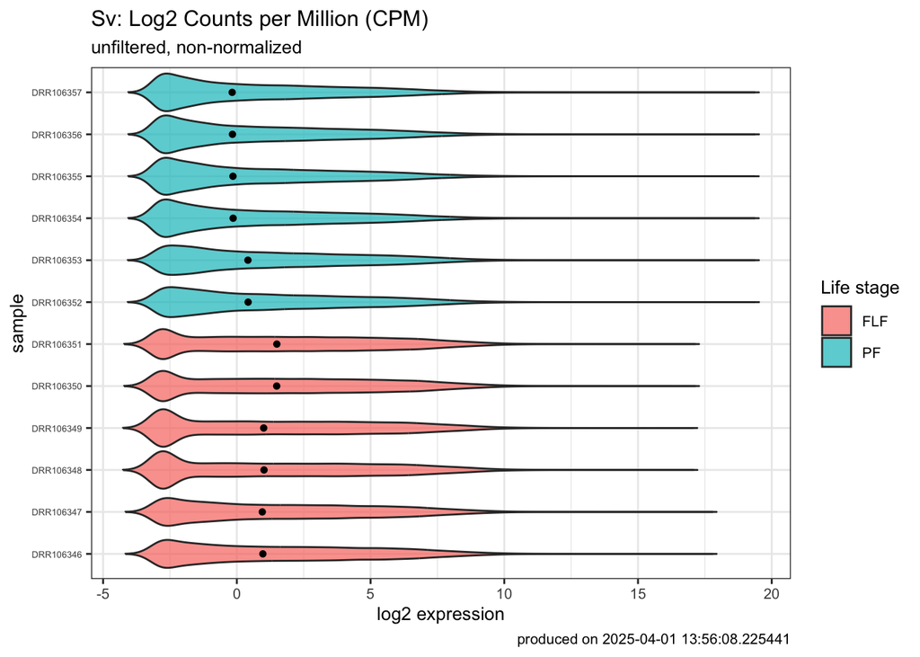

### 4.3.2 Filtered, non-normalized log2CPM data

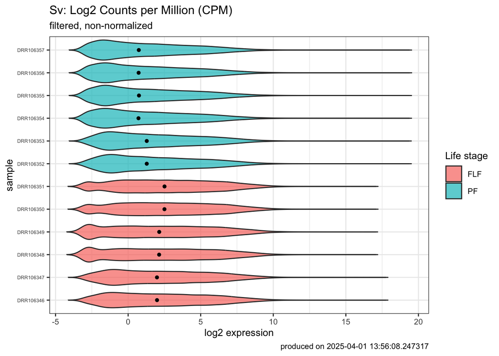

### 4.3.3 Filtered, normalized log2CPM data by life stage

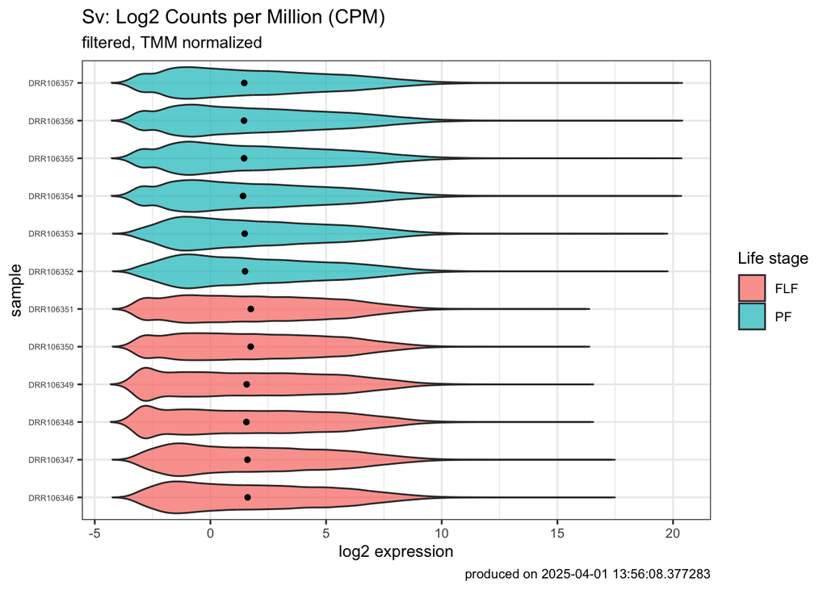

### 4.3.4 Genes discarded by low-copy filtering step

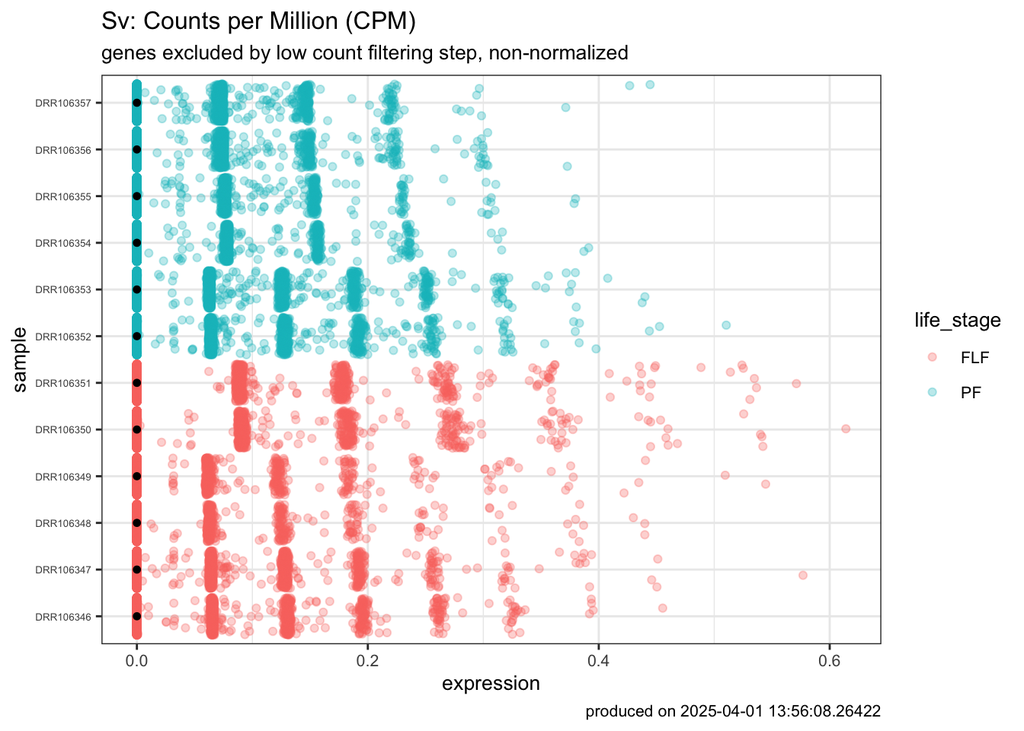

### 4.3.5 Discarded gene list

| geneID | FLF-DRR106346 | FLF-DRR106347 | FLF-DRR106348 | FLF-DRR106349 | FLF-DRR106350 | FLF-DRR106351 | PF-DRR106352 | PF-DRR106353 | PF-DRR106354 | PF-DRR106355 | PF-DRR106356 | PF-DRR106357 | Location | Description | InterPro | GO_term | UniProtKB | GS1_homologID | GS1_percent_homology | GS2_homologID | GS2_percent_homology | GS3_homologID | GS3_percent_homology | GS4_homologID | GS4_percent_homology |
| --- | --- | --- | --- | --- | --- | --- | --- | --- | --- | --- | --- | --- | --- | --- | --- | --- | --- | --- | --- | --- | --- | --- | --- | --- | --- |
| SVE_0000052350 | 0.06302078330653749 | 0.06293954085910076 | 0.1976656134950424 | 0.3235747012611894 | 0.09109526601271709 | 0.08860547497647984 | 0.1188168977072256 | 0 | 0 | 0 | 0 | 0 | SVE_scaffold0000010 | Mobile element protein |  |  | A0A0K0ETT0 |  |  |  |  |  |  |  |  |
| SVE_0000062250 | 0 | 0 | 0 | 0 | 0 | 0 | 0 | 0 | 0 | 0 | 0 | 0 | SVE_scaffold0000011 |  |  |  | A0A0K0ETT1 |  |  |  |  |  |  |  |  |
| SVE_0000063250 | 0.1330836142931558 | 0 | 0 | 0 | 0 | 0 | 0.06578136747118479 | 0.06391985106316544 | 0 | 0.07620086350280746 | 0 | 0.07024348247049997 | SVE_scaffold0000011 | Secreted protein |  | membrane | A0A0K0ETT2 |  |  |  |  |  |  |  |  |
| SVE_0000115450 | 0 | 0.06448823131284388 | 0.2036473632773301 | 0.06696715476871508 | 0.094871873403775 | 0.0908414176375405 | 0.06126511317272329 | 0.06027493436596117 | 0 | 0 | 0.1254713766920862 | 0 | SVE_scaffold0000013 |  |  | membrane | A0A0K0ETT6 |  |  |  |  |  |  |  |  |
| SVE_0000131050 | 0 | 0.1269488652369276 | 0.06793369744198159 | 0 | 0.09512035878344348 | 0 | 0 | 0.06081307334754173 | 0.07192940821071711 | 0 | 0 | 0 | SVE_scaffold0000013 |  |  |  | A0A0K0ETT8 |  |  |  |  |  |  |  |  |
| SVE_0000176450 | 0.06457938146879882 | 0.06430894827453408 | 0 | 0 | 0 | 0 | 0 | 0 | 0 | 0 | 0 | 0 | SVE_scaffold0000016 | Fucosyltransferase | Glyco_trans_10, GT10-like_C_sf | protein glycosylation, fucosyltransferase activity, membrane, Golgi cisterna membrane, glycosyltransferase activity, Golgi apparatus, transferase activity | A0A0K0ETT9 |  |  | SRAE_2000477350 \| WBGene00265017 | 42.029 |  |  |  |  |
| SVE_0000332450 | 0.1464198815390123 | 0 | 0 | 0 | 0 | 0 | 0 | 0 | 0 | 0.07415485198637174 | 0 | 0.06576575158921835 | SVE_scaffold0000024 | IS4 family transposase |  |  | A0A0K0ETU9 |  |  |  |  |  |  |  |  |
| SVE_0000382550 | 0.06213232635209938 | 0.06242501765393395 | 0.06502344531879563 | 0.06352214664183858 | 0 | 0.08787099110876806 | 0 | 0 | 0 | 0 | 0 | 0 | SVE_scaffold0000028 |  |  |  | A0A0K0ETV0 |  |  |  |  |  |  |  |  |
| SVE_0000399650 | 0.07319997363357107 | 0 | 0 | 0 | 0 | 0 | 0 | 0 | 0 | 0 | 0 | 0.0635628762976337 | SVE_scaffold0000001 |  |  |  | A0A0K0ETV3 |  |  |  |  |  |  |  |  |
| SVE_0000434133 | 0 | 0 | 0.1908713361260896 | 0 | 0 | 0 | 0 | 0 | 0 | 0 | 0 | 0 | SVE_scaffold0000001 |  |  |  | A0A0K0ETV5 |  |  |  |  |  |  |  |  |

[output cut: 2707 more lines]

## 4.4 *S. papillosus* Filtering Results

### 4.4.1 Unfiltered, non-normalized log2CPM data

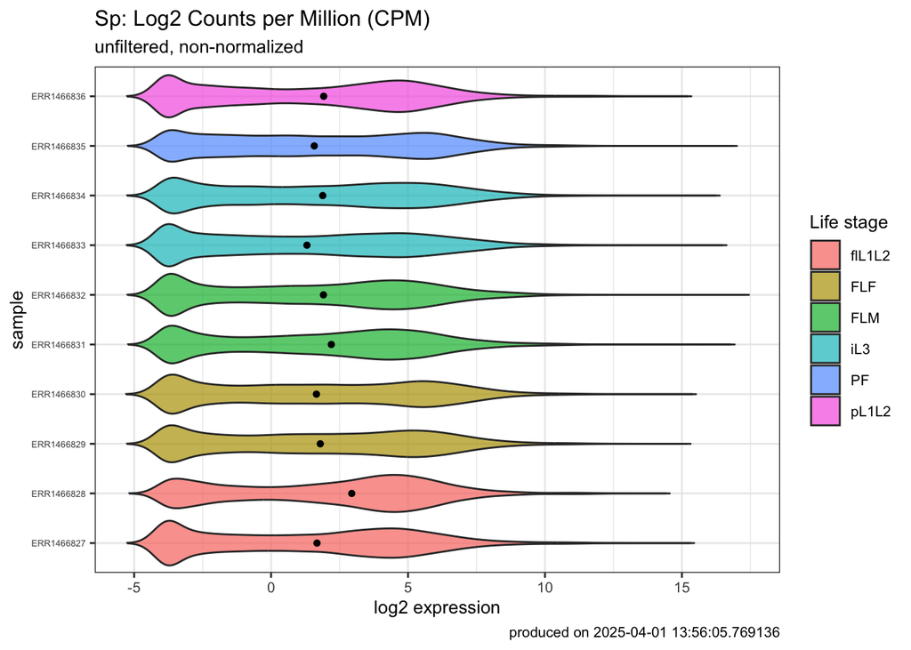

### 4.4.2 Filtered, non-normalized log2CPM data

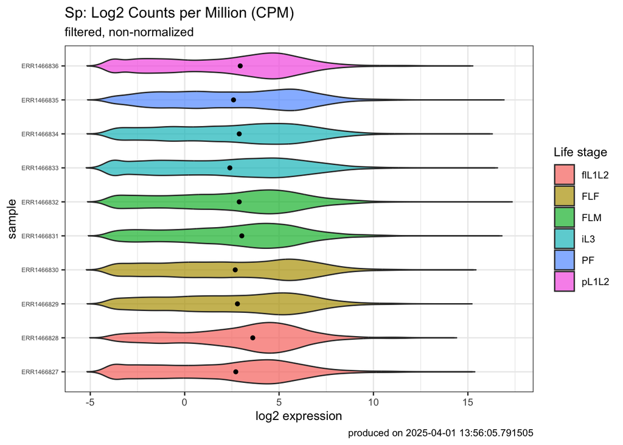

### 4.4.3 Filtered, normalized log2CPM data by life stage

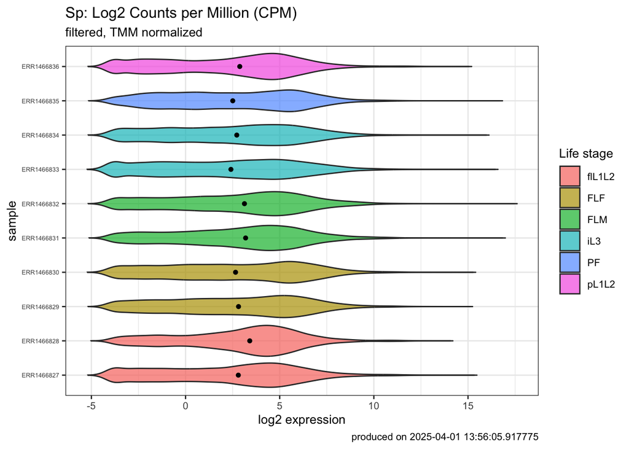

### 4.4.4 Genes discarded by low-copy filtering step

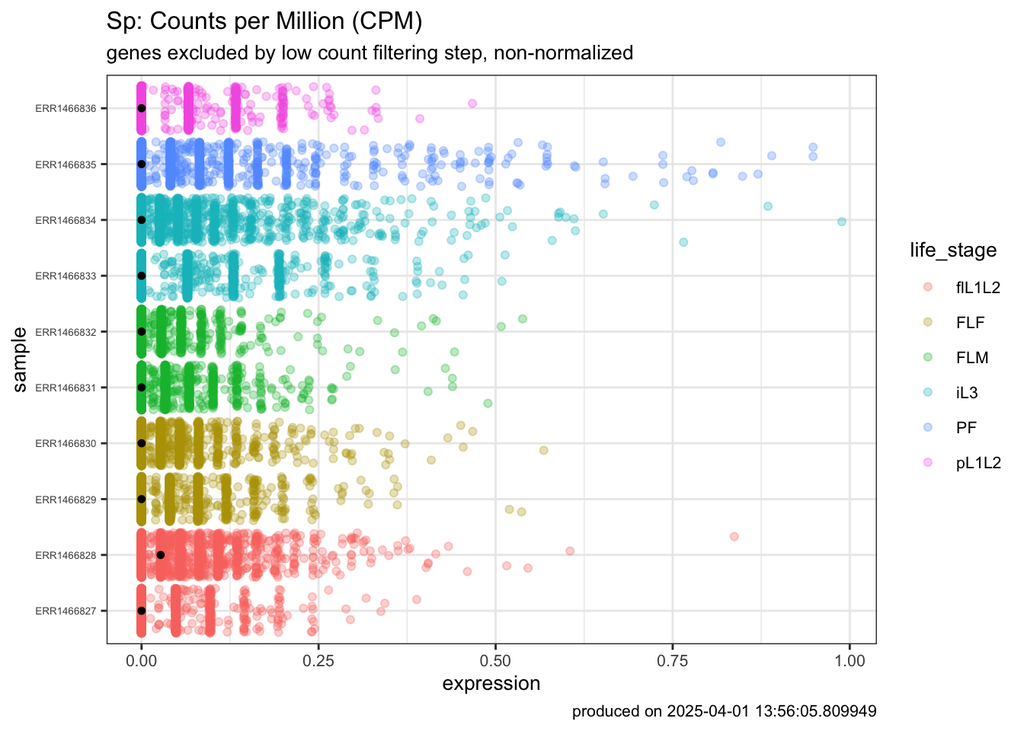

### 4.4.5 Discarded gene list

| geneID | flL1L2-ERR1466827 | flL1L2-ERR1466828 | FLF-ERR1466829 | FLF-ERR1466830 | FLM-ERR1466831 | FLM-ERR1466832 | iL3-ERR1466833 | iL3-ERR1466834 | PF-ERR1466835 | pL1L2-ERR1466836 | Location | Description | InterPro | GO_term | UniProtKB | GS1_homologID | GS1_percent_homology | GS2_homologID | GS2_percent_homology | GS3_homologID | GS3_percent_homology | GS4_homologID | GS4_percent_homology |
| --- | --- | --- | --- | --- | --- | --- | --- | --- | --- | --- | --- | --- | --- | --- | --- | --- | --- | --- | --- | --- | --- | --- | --- |
| SPAL_0000000200 | 0 | 0.05542305946805883 | 0 | 0 | 0.03355787448570324 | 0.05540996245034427 | 0 | 0 | 0 | 0 | SPAL_contig0002041 | Peptidase A1 domain-containing protein |  |  | A0A0N5B1P6 | SSTP_0001018100 | 23 | SRAE_2000420700 \| WBGene00264436 | 20 | SVE_0884900 | 71 |  |  |
| SPAL_0000000500 | 0 | 0 | 0 | 0 | 0 | 0 | 0 | 0 | 0 | 0 | SPAL_contig0002193 | BRCT domain-containing protein |  |  | A0A0N5B1P9 |  |  |  |  | SVE_0764700 | 22.0974 |  |  |
| SPAL_0000000650 | 0.09738165065702868 | 0.05552600797700554 | 0 | 0 | 0 | 0 | 0.06439457536866762 | 0.0750770434940809 | 0.0405910693261624 | 0.06593901529067367 | SPAL_contig0000429 | Ovule protein |  |  | A0A0N5B1Q1 |  |  |  |  |  |  |  |  |
| SPAL_0000000800 | 0.0973483000904499 | 0.05421178967171066 | 0 | 0.05352593064086083 | 0.03374714669005228 | 0.1680207682674894 | 0 | 0.1547498967355866 | 0 | 0.06691573087335574 | SPAL_contig0000429 | DDE-1 domain-containing protein |  |  | A0A0N5B1Q3 |  |  |  |  | SVE_0760600 | 52.6012 |  |  |
| SPAL_0000000900 | 0 | 0.04495869312603148 | 0 | 0 | 0 | 0 | 0.0432752239498698 | 0.008572400335290421 | 0 | 0 | SPAL_contig0000986 |  |  |  | A0A0N5CFM3 |  |  |  |  |  |  |  |  |
| SPAL_0000001000 | 0 | 0 | 0.04033516188397175 | 0.02659512354604083 | 0 | 0 | 0 | 0 | 0 | 0 | SPAL_contig0002265 | Thymidylate kinase |  |  | A0A0N5B1Q5 |  |  |  |  | SVE_1454200 | 88.9764 |  |  |
| SPAL_0000001100 | 0 | 0.0809705257304646 | 0.03979119120607826 | 0.05390581328260452 | 0.06758530012201938 | 0.02817651745955705 | 0 | 0 | 0.04100126966372757 | 0 | SPAL_contig0002265 | ING domain-containing protein |  |  | A0A0N5B1Q6 |  |  |  |  | SVE_1453400 | 39.0511 |  |  |
| SPAL_0000001200 | 0 | 0.02799402591319556 | 0 | 0 | 0 | 0.02720807336275474 | 0 | 0 | 0 | 0 | SPAL_contig0003159 | RNase H domain-containing protein |  |  | A0A0N5B1Q7 |  |  |  |  |  |  |  |  |
| SPAL_0000001300 | 0 | 0.2229656810689655 | 0.07969011463994698 | 0.0623243774828819 | 0.03373140343013779 | 0 | 0.1948965529700796 | 0.04923879792257557 | 0 | 0 | SPAL_contig0002880 | RGS domain-containing protein |  |  | A0A0N5B1Q8 | SSTP_0000702700 | 40.7407 |  |  | SVE_1474200 | 32.4074 |  |  |
| SPAL_0000001400 | 0.09814524933190621 | 0.109685190409661 | 0.04027579391422987 | 0.02637138976296444 | 0.06686885770182383 | 0.05511675032820827 | 0.1306560763568854 | 0.02540920624879139 | 0.04098691546418475 | 0.2011909520108218 | SPAL_contig0000313 | Ovule protein |  |  | A0A0N5B1R0 |  |  |  |  |  |  |  |  |

[output cut: 2574 more lines]

# 5 Hierarchical Clustering and Principle Components Analysis Results

## 5.1 *S. stercoralis* PCA Results

### 5.1.1 Dendrogram to visualize hierachical clustering

Clustering performed on filtered and normalized abundance data using the “complete” method.

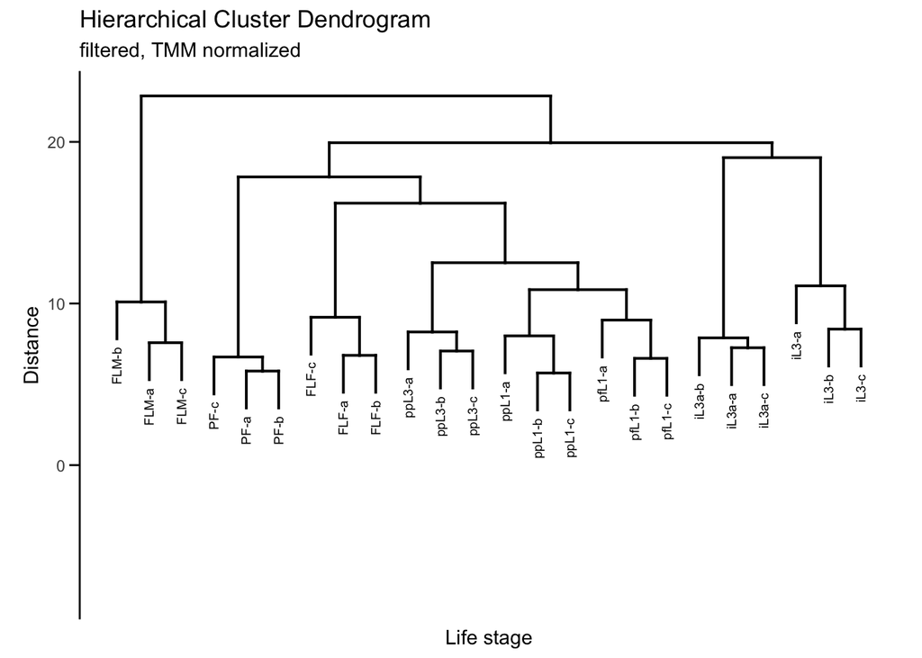

### 5.1.2 Screeplot of PCA Eigenvalues

A scree plot is a standard way to view eigenvalues for each PCA. The plot shows the proportion of variance accounted for by each PC.

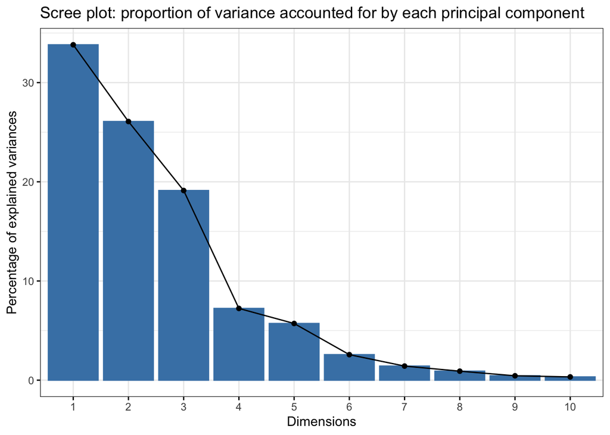

### 5.1.3 PCA Plot

Plot of the samples in PCA space. Fill color indicates life stage.

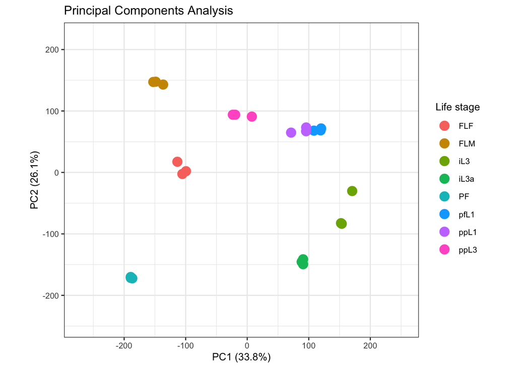

### 5.1.4 PCA “Small Multiples” Plot

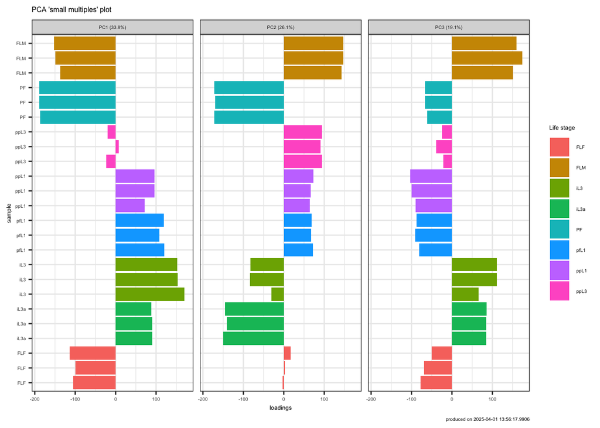

## 5.2 *S. ratti* PCA Results

### 5.2.1 Dendrogram to visualize hierachical clustering

Clustering performed on filtered and normalized abundance data using the “complete” method.

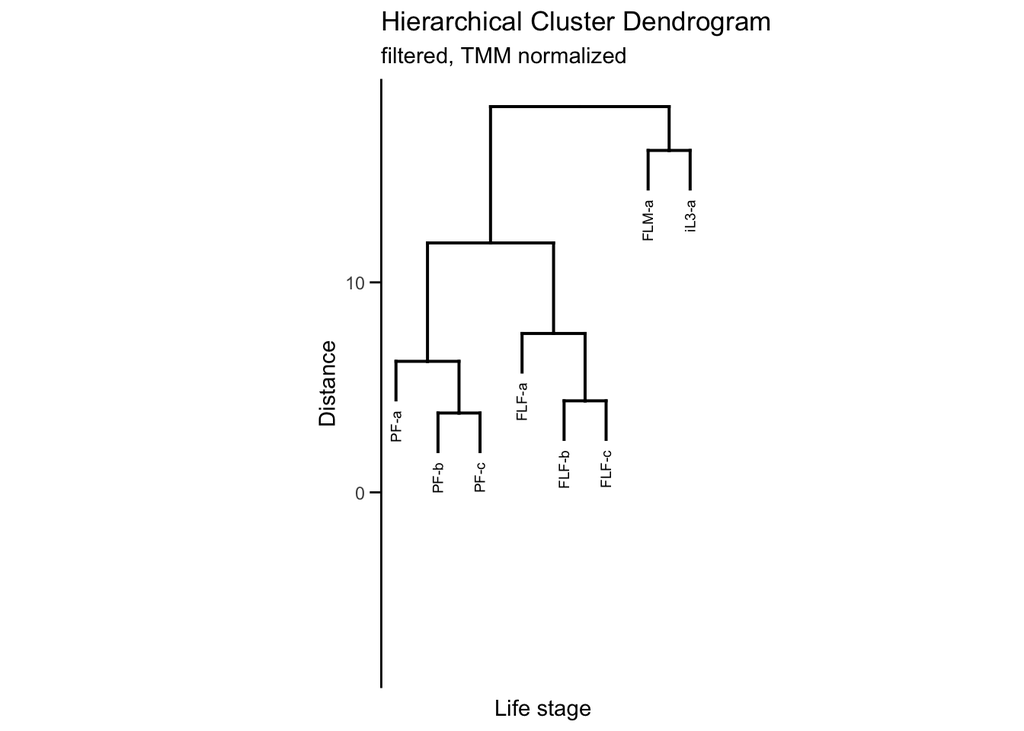

### 5.2.2 Screeplot of PCA Eigenvalues

A scree plot is a standard way to view eigenvalues for each PCA. The plot shows the proportion of variance accounted for by each PC.

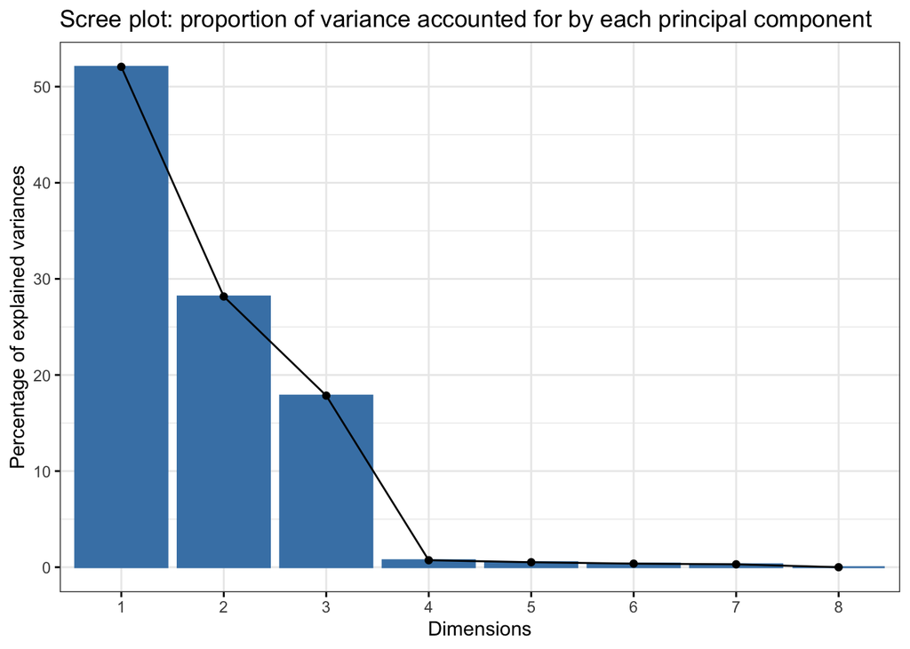

### 5.2.3 PCA Plot

Plot of the samples in PCA space. Fill color indicates life stage.

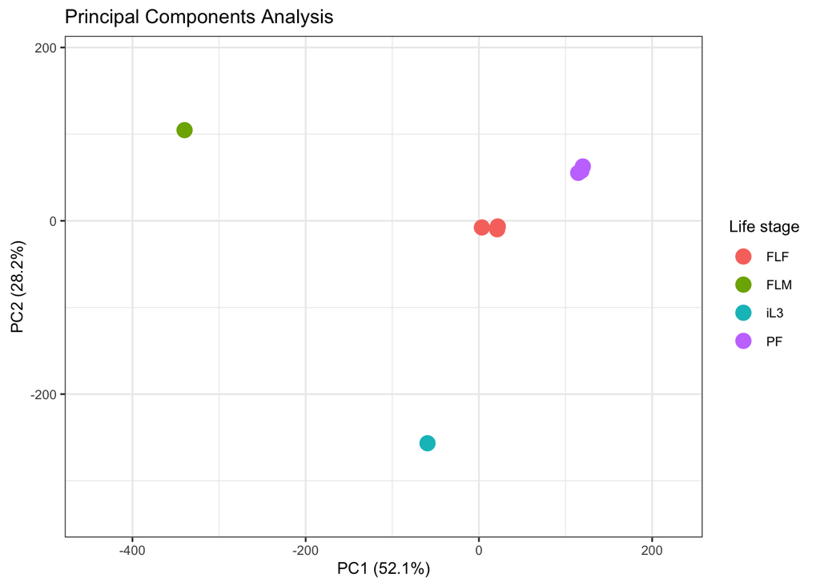

### 5.2.4 PCA “Small Multiples” Plot

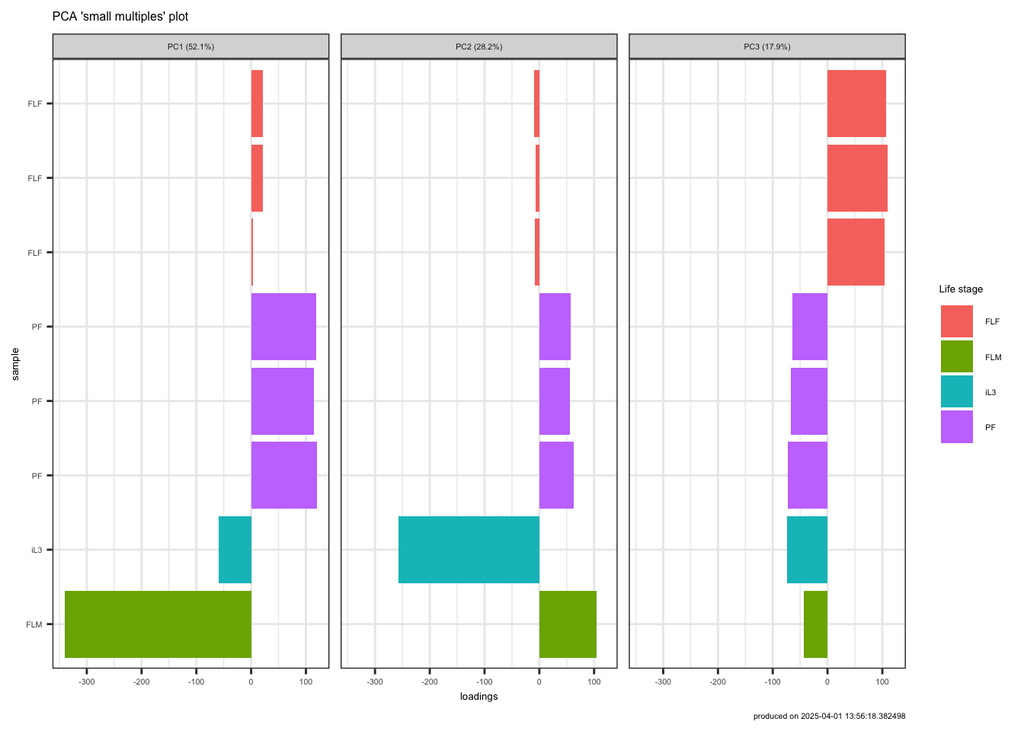

## 5.3 *S. venezuelensis* PCA Results

### 5.3.1 Dendrogram to visualize hierachical clustering

Clustering performed on filtered and normalized abundance data using the “complete” method.

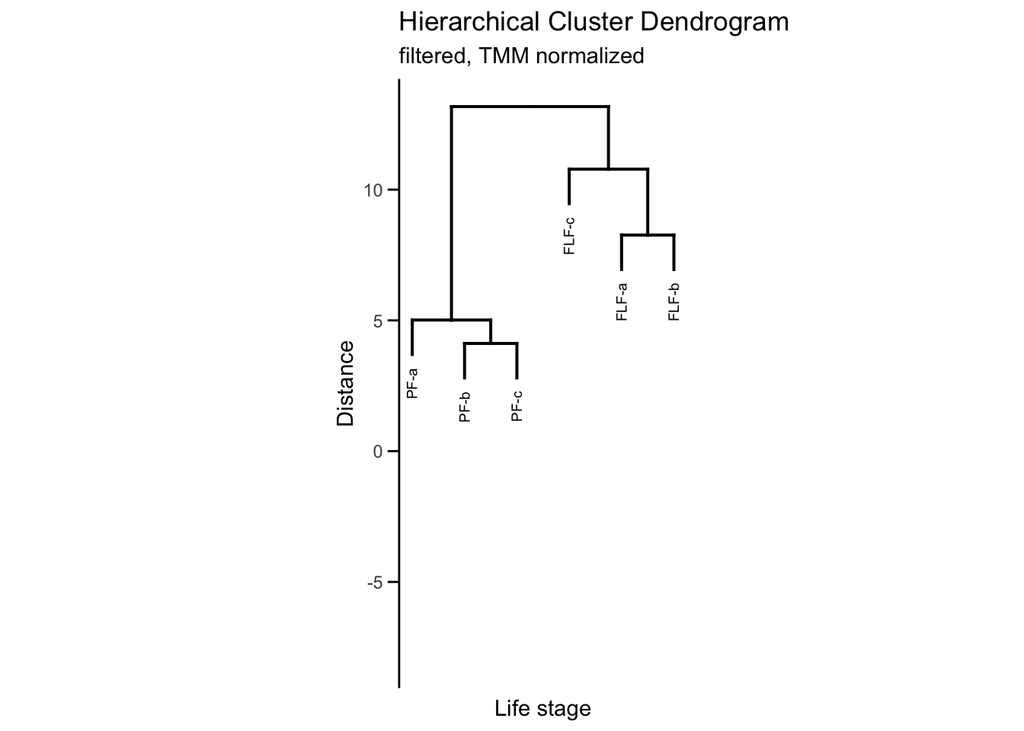

### 5.3.2 Screeplot of PCA Eigenvalues

A scree plot is a standard way to view eigenvalues for each PCA. The plot shows the proportion of variance accounted for by each PC.

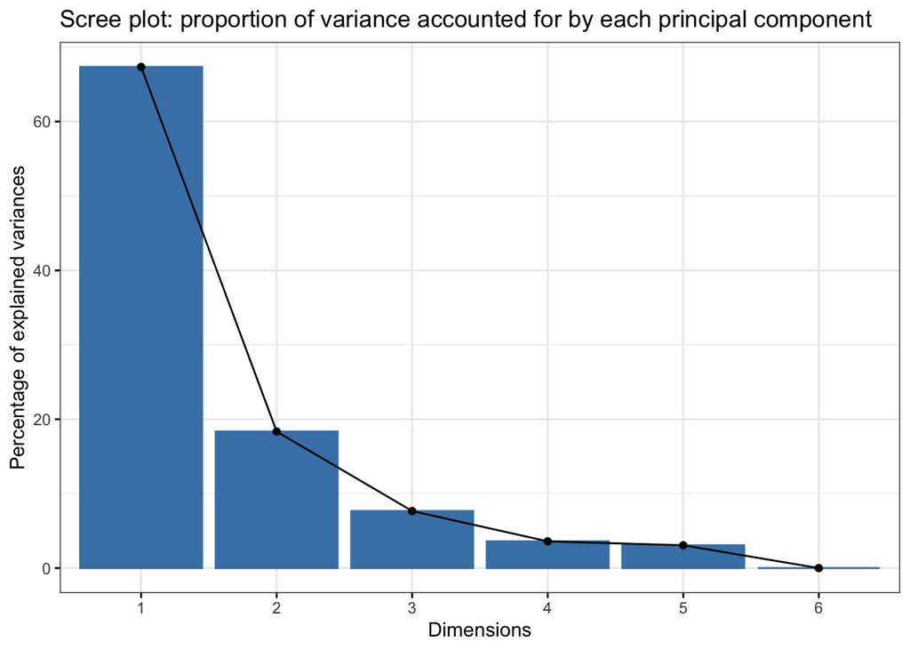

### 5.3.3 PCA Plot

Plot of the samples in PCA space. Fill color indicates life stage.

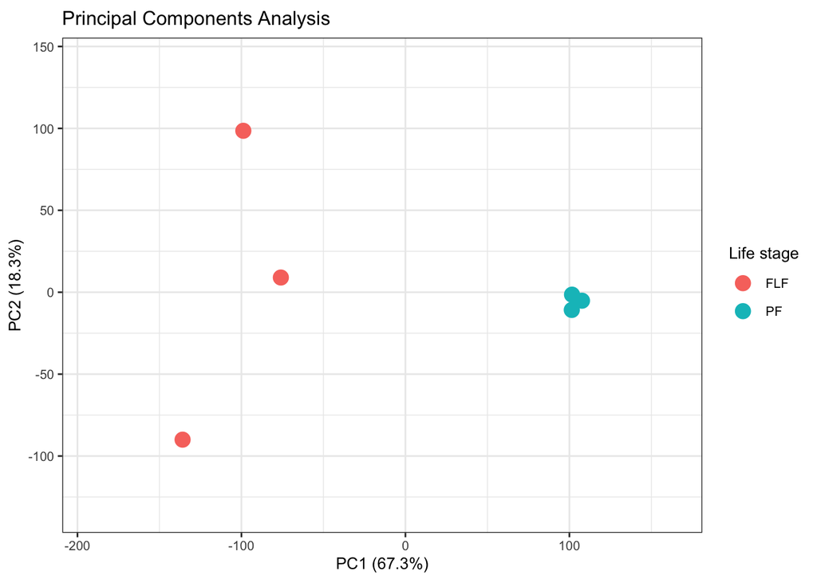

### 5.3.4 PCA “Small Multiples” Plot

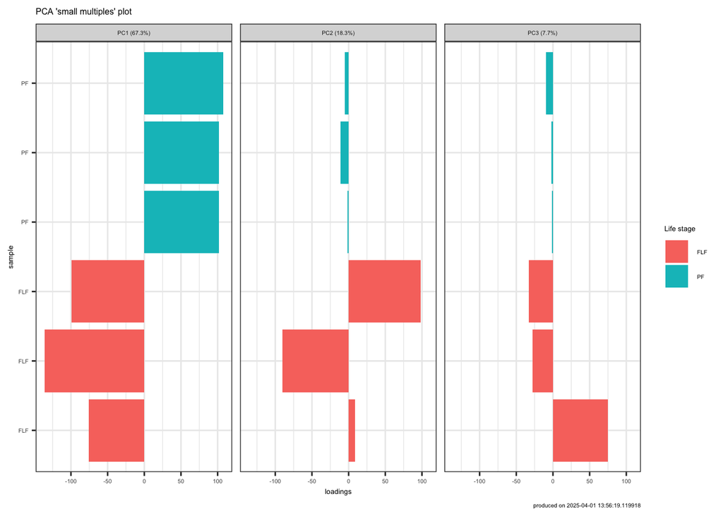